# Vestibular colocalization and gene info

## Colocalization

I used [fastENLOC](https://github.com/xqwen/fastenloc) to test for colocalization of GWAS associations with cis-eQTLs in 49 GTEx tissues. Colocalization was run separately for each tissue.

fastENLOC uses Bayesian statistics and reports colocalizations at the SNP, locus, and gene level, but the main result is RCP, regional colocalization probability, per gene. It is the probability that any single SNP in the region is causal for both signals. That means that if the GWAS and eQTL signals are spread across multiple SNPs in high LD, the RCP will not be high because the probability of any one of the SNPs being causal for both is not high.

| tissue | gene_id | RCP |
| --- | --- | --- |
| Artery_Aorta | ENSG00000204682 | 0.06839 |
| Skin_Sun_Exposed | ENSG00000078403 | 0.06400 |
| Thyroid | ENSG00000078403 | 0.02491 |
| Adrenal_Gland | ENSG00000180592 | 0.02468 |
| Muscle_Skeletal | ENSG00000196653 | 0.01696 |
| Artery_Coronary | ENSG00000180592 | 0.01657 |
| Adipose_Subcutaneous | ENSG00000196653 | 0.01645 |
| Artery_Tibial | ENSG00000204682 | 0.01565 |
| Breast_Mammary_Tissue | ENSG00000078403 | 0.01564 |
| Nerve_Tibial | ENSG00000196653 | 0.01526 |

[output cut: 16 more lines]

Showing only maximum RCP per gene in any tissue:

| tissue | gene_id | RCP |
| --- | --- | --- |
| Artery_Aorta | ENSG00000204682 | 0.06839 |
| Skin_Sun_Exposed | ENSG00000078403 | 0.06400 |
| Adrenal_Gland | ENSG00000180592 | 0.02468 |
| Muscle_Skeletal | ENSG00000196653 | 0.01696 |
| Esophagus_Mucosa | ENSG00000169964 | 0.01447 |
| Testis | ENSG00000232040 | 0.01423 |
| Brain_Cerebellum | ENSG00000214820 | 0.01328 |
| Cells_Cultured_fibroblasts | ENSG00000144792 | 0.01274 |
| Esophagus_Mucosa | ENSG00000270021 | 0.01104 |

| gene_id | gene_name | chrom | tss | synonym | description |
| --- | --- | --- | --- | --- | --- |
| ENSG00000204682 | MIR1915HG | 10 | 21497260 | bA418C1.3; C10orf114; CASC10 | MIR1915 host gene [Source:HGNC Symbol;Acc:HGNC:31448] |
| ENSG00000078403 | MLLT10 | 10 | 21534645 | AF10 | MLLT10 histone lysine methyltransferase DOT1L cofactor [Source:HGNC Symbol;Acc:HGNC:16063] |
| ENSG00000180592 | SKIDA1 | 10 | 21525682 | C10orf140; FLJ45187 | SKI/DACH domain containing 1 [Source:HGNC Symbol;Acc:HGNC:32697] |
| ENSG00000196653 | ZNF502 | 3 | 44712643 | FLJ12515; FLJ14855 | zinc finger protein 502 [Source:HGNC Symbol;Acc:HGNC:23718] |
| ENSG00000169964 | TMEM42 | 3 | 44861904 | MGC29956 | transmembrane protein 42 [Source:HGNC Symbol;Acc:HGNC:28444] |
| ENSG00000232040 | ZBED9 | 6 | 28616212 | Buster4; FLJ31087; KIAA1925; SCAND3; ZFP38-L; ZNF305P2; ZNF452 | zinc finger BED-type containing 9 [Source:HGNC Symbol;Acc:HGNC:13851] |
| ENSG00000214820 | MPRIPP1 | 3 | 12282728 | NA | myosin phosphatase Rho interacting protein pseudogene 1 [Source:HGNC Symbol;Acc:HGNC:44594] |
| ENSG00000144792 | ZNF660 | 3 | 44578223 | FLJ36870 | zinc finger protein 660 [Source:HGNC Symbol;Acc:HGNC:26720] |
| ENSG00000270021 | NA | 5 | 57065834 | NA | novel transcript, antisense to H2AFY |

## Predicted genes

I looked at GTEx gene expression, eQTLs, and sQTLs for the predicted genes within GWAS loci from the paper.

I’m replacing KPNA17 with KPNA2, since I can’t find KPNA17, and KPNA2 is in the QTL region. I’m also ignoring COMMD3-BMI1, which is a readthrough transcript of two other predicted genes, and it isn’t in the GTEx data.

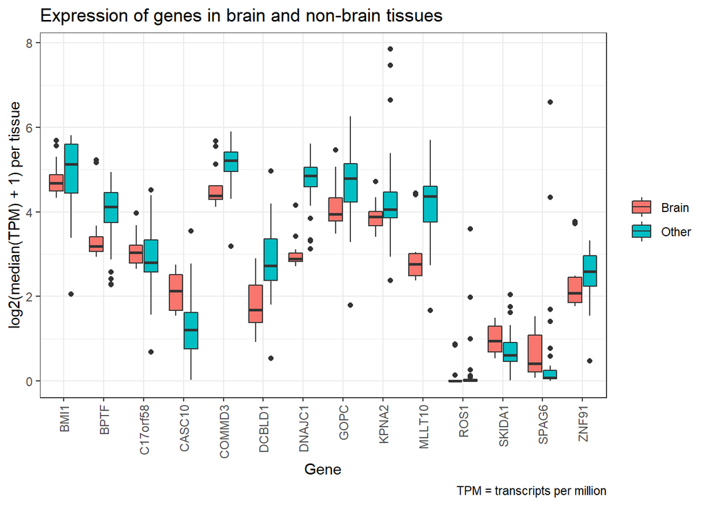

#### cis-eQTLs

For some genes, multiple independent cis-eQTLs were found in the same tissue.

| tissue | gene_id | gene_name | variant_id | pval_beta |
| --- | --- | --- | --- | --- |
| Adipose_Subcutaneous | ENSG00000164465.18 | DCBLD1 | chr6_117496002_C_T_b38 | 1.01821e-27 |
| Adipose_Subcutaneous | ENSG00000047932.13 | GOPC | chr6_117600440_C_T_b38 | 3.75384e-11 |
| Adipose_Subcutaneous | ENSG00000182481.8 | KPNA2 | chr17_68128187_C_T_b38 | 1.10393e-02 |
| Adipose_Subcutaneous | ENSG00000182481.8 | KPNA2 | chr17_68975847_T_G_b38 | 4.20713e-02 |
| Adipose_Subcutaneous | ENSG00000167232.13 | ZNF91 | chr19_23452169_G_A_b38 | 2.75003e-03 |
| Adipose_Visceral_Omentum | ENSG00000164465.18 | DCBLD1 | chr6_117493857_T_A_b38 | 3.40776e-23 |
| Adipose_Visceral_Omentum | ENSG00000047932.13 | GOPC | chr6_117548123_G_T_b38 | 5.28258e-04 |
| Adipose_Visceral_Omentum | ENSG00000167232.13 | ZNF91 | chr19_23304038_T_G_b38 | 1.40521e-03 |
| Adrenal_Gland | ENSG00000047932.13 | GOPC | chr6_117559536_A_G_b38 | 1.38815e-02 |
| Adrenal_Gland | ENSG00000171634.16 | BPTF | chr17_67635554_A_C_b38 | 3.64498e-02 |

[output cut: 199 more lines]

#### cis-sQTLs

These are variants associated with altered usage of splice junctions within a gene. For some genes, multiple independent cis-sQTLs were found in the same tissue.

| tissue | gene_id | gene_name | variant_id | pval_beta |
| --- | --- | --- | --- | --- |
| Adipose_Subcutaneous | ENSG00000164465.18 | DCBLD1 | chr6_117544978_A_G_b38 | 4.46042e-03 |
| Adipose_Subcutaneous | ENSG00000164465.18 | DCBLD1 | chr6_118121692_C_T_b38 | 3.55254e-02 |
| Adipose_Subcutaneous | ENSG00000047932.13 | GOPC | chr6_117619871_G_T_b38 | 1.30202e-04 |
| Adipose_Subcutaneous | ENSG00000167232.13 | ZNF91 | chr19_22792643_G_C_b38 | 2.67920e-02 |
| Artery_Aorta | ENSG00000047932.13 | GOPC | chr6_117619871_G_T_b38 | 1.49824e-05 |
| Artery_Tibial | ENSG00000047932.13 | GOPC | chr6_117633018_G_A_b38 | 1.38630e-10 |
| Artery_Tibial | ENSG00000047932.13 | GOPC | chr6_117577029_C_CACAT_b38 | 1.89839e-02 |
| Artery_Tibial | ENSG00000171634.16 | BPTF | chr17_68396878_G_A_b38 | 3.96275e-02 |
| Brain_Cerebellar_Hemisphere | ENSG00000167232.13 | ZNF91 | chr19_23374268_A_G_b38 | 3.48927e-04 |
| Brain_Hypothalamus | ENSG00000148444.15 | COMMD3 | chr10_22764498_A_G_b38 | 5.54260e-03 |

[output cut: 28 more lines]